# EDA

CJ

2023-12-05

Import nessecary libraries

```r
library (ggplot2)
library (dplyr)
library(tidyverse)
library(naniar)
library(corrplot)
library(e1071)
```

Import CSV and Check for missing values

```r
csd=read.csv("/Users/christopherjohnson/Downloads/CaseStudy2-data.csv",header = TRUE)
csd
```

[output not shown]

[output cut: 6953 more lines]

```r
miss_var_summary(csd)
```

```
## # A tibble: 36 × 3
##    variable         n_miss pct_miss
##    <chr>             <int>    <dbl>
##  1 ID                    0        0
##  2 Age                   0        0
##  3 Attrition             0        0
##  4 BusinessTravel        0        0
##  5 DailyRate             0        0
##  6 Department            0        0
##  7 DistanceFromHome      0        0
##  8 Education             0        0
##  9 EducationField        0        0
## 10 EmployeeCount         0        0
## # ℹ 26 more rows
```

No missing data found

Calculate percentage of current attrition

```r
atr=table(csd$Attrition)
atr/sum(atr)*100
```

```
##
##       No      Yes
## 83.90805 16.09195
```

Significantly more No attrition than Yes attrition

Remove columns that have the same value throughout data (Over18, Standardhours, Employeecount)

```r
csd2=csd[,-c(10, 23, 28 )]
```

String Columns by attrition

```r
csd2$Attrition <- as.factor(csd2$Attrition)
# Identify string columns
string_columns <- sapply(csd2, is.character)

# Calculate percent attrition for each unique value in each string column
attrition_percentages <- lapply(names(csd2)[string_columns], function(column) {
  # For each unique value in the column
  unique_values <- unique(csd2[[column]])

  sapply(unique_values, function(value) {
    # Subset the data for the specific value
    subset_data <- csd2[csd2[[column]] == value, ]

    # Calculate percent attrition
    percent_attrition <- sum(subset_data$Attrition == "Yes") / nrow(subset_data) * 100

    return(percent_attrition)
  }, USE.NAMES = TRUE)
})

# Result
attrition_percentages
```

```
## [[1]]
##     Travel_Rarely Travel_Frequently        Non-Travel
##          15.21036          22.15190          11.70213
##
## [[2]]
##                  Sales Research & Development        Human Resources
##               21.61172               13.34520               17.14286
##
## [[3]]
##    Life Sciences          Medical        Marketing Technical Degree
##         14.80447         13.70370         20.00000         22.66667
##            Other  Human Resources
##         17.30769         26.66667
##
## [[4]]
##     Male   Female
## 16.86047 14.97175
##
## [[5]]
##           Sales Executive         Research Director    Manufacturing Director
##                 16.500000                  1.960784                  2.298851
##        Research Scientist      Sales Representative Healthcare Representative
##                 18.604651                 45.283019                 10.526316
##                   Manager           Human Resources     Laboratory Technician
##                  7.843137                 22.222222                 19.607843
##
## [[6]]
##  Divorced    Single   Married
##  6.282723 26.022305 14.146341
##
## [[7]]
##        No       Yes
##  9.708738 31.746032
```

Plot attrition percentage

```r
data_summary <- csd2%>%
  select(Attrition, BusinessTravel, Department, EducationField, Gender, JobRole, MaritalStatus, OverTime) %>%
  pivot_longer(cols = -Attrition, names_to = "Variable", values_to = "Level") %>%
  group_by(Variable, Level) %>%
  summarise(Attrition_Count = sum(Attrition == "Yes"), Total_Count = n()) %>%
  mutate(Attrition_Percent = Attrition_Count / Total_Count * 100)
```

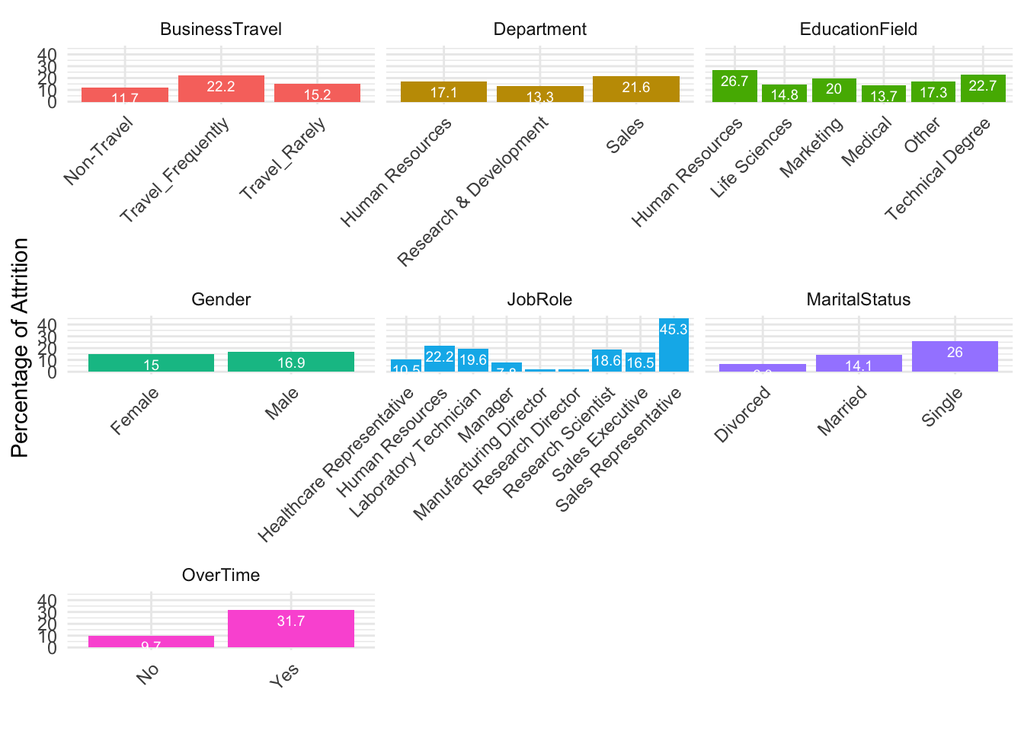

```r
# Plot
ggplot(data_summary, aes(x = Level, y = Attrition_Percent, fill = Variable)) +
  geom_bar(stat = "identity", position = position_dodge()) +
  geom_text(aes(label = round(Attrition_Percent,1)), vjust = 1.5, size = 2.5, color="white")+
  facet_wrap(~ Variable, scales = "free_x") +
  theme_minimal() +
  theme(axis.text.x = element_text(angle = 45, hjust = 1),legend.position = "none") +
  labs(y = "Percentage of Attrition", x = "")
```

ompared ranges of lowest percentages of attrition to highest for each catagory The two highest differences were Overtime (~22%) and JobTitle (~43%) Lowest catagorical variables non-travel, R&D, Medical Degree, Female, Research Director, Divorced, no-OT Highest catagorical variables travel-frequently, sales, Human Resource Degree, Sales Rep, Single, OT

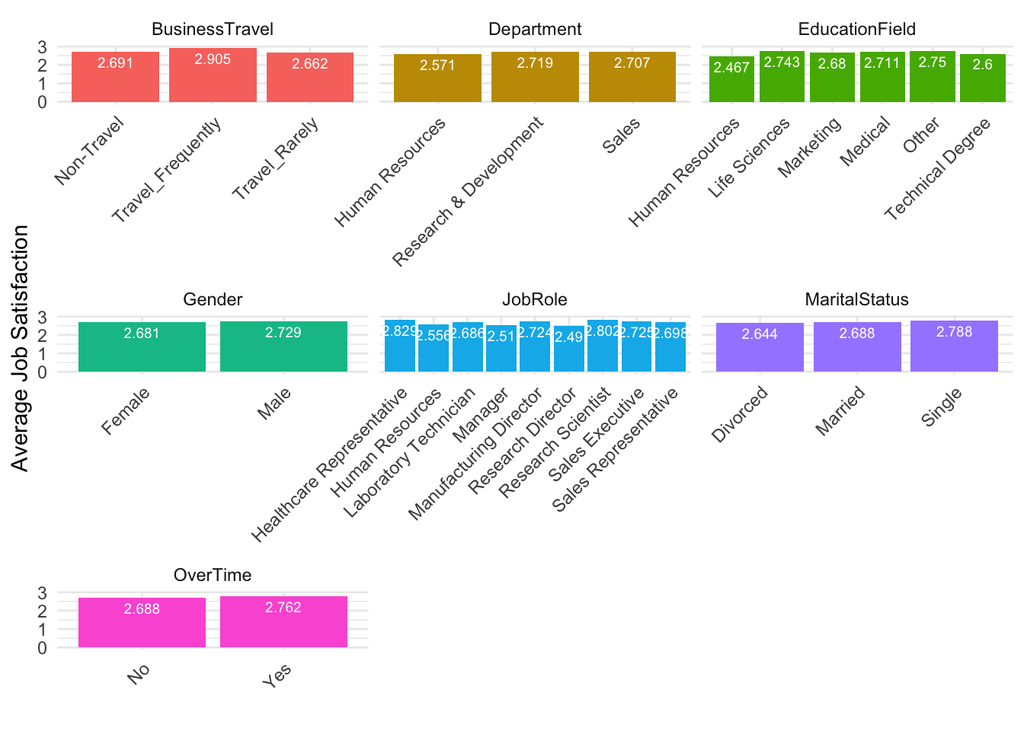

```r
data_summary <- csd2 %>%
  select(JobSatisfaction, BusinessTravel, Department, EducationField, Gender, JobRole, MaritalStatus, OverTime) %>%
  pivot_longer(cols = -JobSatisfaction, names_to = "Variable", values_to = "Level") %>%
  group_by(Variable, Level) %>%
  summarise(Average_JobSatisfaction = mean(JobSatisfaction, na.rm = TRUE), .groups = 'drop')

# Plot
ggplot(data_summary, aes(x = Level, y = Average_JobSatisfaction, fill = Variable)) +
  geom_col( position = position_dodge()) +
  facet_wrap(~ Variable, scales = "free_x") +
  theme_minimal()+
  geom_text(aes(label = round(Average_JobSatisfaction, 3)), vjust = 1.5, size = 2.5, color="white")+
  theme(axis.text.x = element_text(angle = 45, hjust = 1), legend.position = "none") +
  labs(y = "Average Job Satisfaction", x = "")
```

Create Correlation matrix and plot

```r
csd2$AtrBin = ifelse(csd2$Attrition == "Yes", 100, 0) #Change attrition to binary
numcol =sapply(csd2, is.numeric) #find only columns with numeric values
csd3=csd2[,numcol] #create new dataframe
corr=cor(csd3) # find corrlation
cordf=as.data.frame(as.table(corr)) #create new dataframe for plotting
cordf2 <- cordf[cordf$Freq != 1, ] #create another data frame in descending order with values equal 1 removed
cordf2 <- cordf2[order(-cordf2$Freq), ]
#See strong correlation betwen monthly income vs job level

cordf2[cordf2$Var1=="AtrBin",] #See correlation between Attrition only and other variables
```

```
##       Var1                     Var2         Freq
## 104 AtrBin         DistanceFromHome  0.087136293
## 364 AtrBin       NumCompaniesWorked  0.061018887
## 26  AtrBin                       ID  0.047266995
## 208 AtrBin               HourlyRate  0.036554178
## 416 AtrBin        PerformanceRating  0.015333837
## 390 AtrBin        PercentSalaryHike  0.015328069
## 624 AtrBin  YearsSinceLastPromotion -0.004573321
## 156 AtrBin           EmployeeNumber -0.022793834
## 78  AtrBin                DailyRate -0.033793125
## 442 AtrBin RelationshipSatisfaction -0.039646611
## 338 AtrBin              MonthlyRate -0.043232173
## 130 AtrBin                Education -0.049442357
## 520 AtrBin    TrainingTimesLastYear -0.062726088
## 182 AtrBin  EnvironmentSatisfaction -0.077325405
## 546 AtrBin          WorkLifeBalance -0.089789709
## 286 AtrBin          JobSatisfaction -0.107520935
## 572 AtrBin           YearsAtCompany -0.128754060
## 650 AtrBin     YearsWithCurrManager -0.146782245
## 468 AtrBin         StockOptionLevel -0.148680303
## 52  AtrBin                      Age -0.149383577
## 312 AtrBin            MonthlyIncome -0.154914955
## 598 AtrBin       YearsInCurrentRole -0.156215707
## 260 AtrBin                 JobLevel -0.162136444
## 494 AtrBin        TotalWorkingYears -0.167206122
## 234 AtrBin           JobInvolvement -0.187793409
```

Distance From home and Num of Companies Worked are the two highest correlation

Plot data

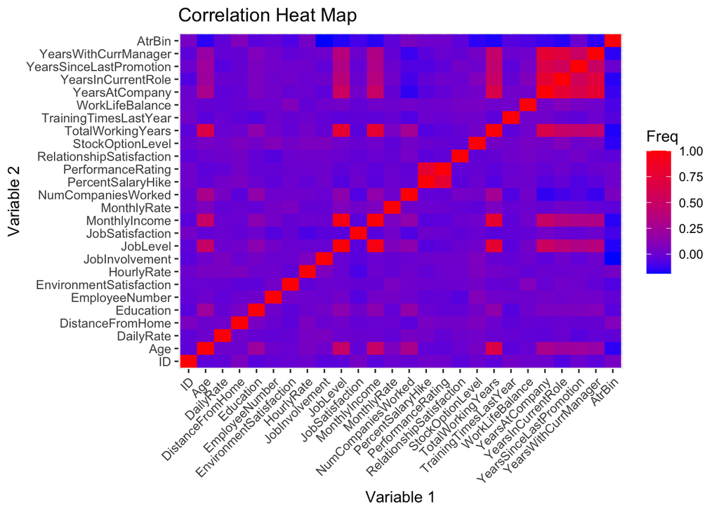

```r
ggplot(cordf, aes(Var1, Var2, fill = Freq)) +
  geom_tile() +
  scale_fill_gradient(low = "blue", high = "red") +
  theme(axis.text.x = element_text(angle = 45, hjust = 1))+
  labs(x="Variable 1", y="Variable 2", title = "Correlation Heat Map")
```

Create KNN model

```r
library(caret)
set.seed(3)



colnames(csd2)
```

```
##  [1] "ID"                       "Age"
##  [3] "Attrition"                "BusinessTravel"
##  [5] "DailyRate"                "Department"
##  [7] "DistanceFromHome"         "Education"
##  [9] "EducationField"           "EmployeeNumber"
## [11] "EnvironmentSatisfaction"  "Gender"
## [13] "HourlyRate"               "JobInvolvement"
## [15] "JobLevel"                 "JobRole"
## [17] "JobSatisfaction"          "MaritalStatus"
## [19] "MonthlyIncome"            "MonthlyRate"
## [21] "NumCompaniesWorked"       "OverTime"
## [23] "PercentSalaryHike"        "PerformanceRating"
## [25] "RelationshipSatisfaction" "StockOptionLevel"
## [27] "TotalWorkingYears"        "TrainingTimesLastYear"
## [29] "WorkLifeBalance"          "YearsAtCompany"
## [31] "YearsInCurrentRole"       "YearsSinceLastPromotion"
## [33] "YearsWithCurrManager"     "AtrBin"
```

```r
csd2$sHourlyRate=scale(csd2$HourlyRate)
csd2$sTotalWorkingYears=scale(csd2$TotalWorkingYears)
csd2$sDistanceFromHome=scale(csd2$DistanceFromHome)
csd2$sAge=scale(csd2$Age)

train_index=createDataPartition(csd2$Attrition, p = 0.7, list = FALSE)
training_data = csd2[train_index, ]
testing_data = csd2[-train_index, ]
testing_data
```

[output not shown]

[output cut: 2343 more lines]

```r
#####knn find best K value for accuracy, Sens(Ales), Spec(IPA)
set.seed(37)
library(class)
mAcc = matrix(nrow = 100)
mSen = matrix(nrow = 100)
mSpec = matrix(nrow = 100)
for (i in 1:100){
  knn_model = knn(train = training_data[, c("sHourlyRate", "sTotalWorkingYears", "sDistanceFromHome", "sAge")], test = testing_data[, c("sHourlyRate", "sTotalWorkingYears", "sDistanceFromHome", "sAge")], cl = training_data$Attrition, k = i)
  CM = confusionMatrix(table(knn_model,testing_data$Attrition))
  mAcc[i]=CM$overall[1]
  mSen[i]=CM$byClass[1]
  mSpec[i]=CM$byClass[2]
}
max(mAcc)
```

```
## [1] 0.8390805
```

```r
max(mSen)
```

```
## [1] 1
```

```r
max(mSpec)
```

```
## [1] 0.2857143
```

KNN Yeilded low Specificity regardless of factors and k values

Reload data with strings as factors and perform NaiveBayes

```r
csd4=read.csv("/Users/christopherjohnson/Downloads/CaseStudy2-data.csv",header = TRUE, stringsAsFactors = TRUE)
set.seed(3)
train_index2=createDataPartition(csd4$Attrition, p = 0.7, list = FALSE)
training_data2 = csd4[train_index2, ]
testing_data2 = csd4[-train_index2, ]
testing_data2
```

[output not shown]

[output cut: 2081 more lines]

```r
model4=naiveBayes(Attrition~., data=training_data2 )
predictions = predict(model4, testing_data2)
confusionMatrix(predictions,testing_data2$Attrition)
```

```
## Confusion Matrix and Statistics
##
##           Reference
## Prediction  No Yes
##        No  195  16
##        Yes  24  26
##
##                Accuracy : 0.8467
##                  95% CI : (0.7972, 0.8882)
##     No Information Rate : 0.8391
##     P-Value [Acc > NIR] : 0.4072
##
##                   Kappa : 0.473
##
##  Mcnemar's Test P-Value : 0.2684
##
##             Sensitivity : 0.8904
##             Specificity : 0.6190
##          Pos Pred Value : 0.9242
##          Neg Pred Value : 0.5200
##              Prevalence : 0.8391
##          Detection Rate : 0.7471
##    Detection Prevalence : 0.8084
##       Balanced Accuracy : 0.7547
##
##        'Positive' Class : No
##
```

Read in no attrition set and predict

```r
valat=read.csv("/Users/christopherjohnson/Downloads/CaseStudy2Compset+No+Attrition.csv",header = TRUE, stringsAsFactors = TRUE)
attritionval=predict(model4,valat)

valat$Attrition=attritionval
write.csv(valat[,c("ID","Attrition")],file="/Users/christopherjohnson/Downloads/Case2PredictionJohnsonAttrition.csv")
```

Salary prediction Plot correlation data to monthlyincome

```r
correlations = cor(csd4[, sapply(csd4, is.numeric)])
```

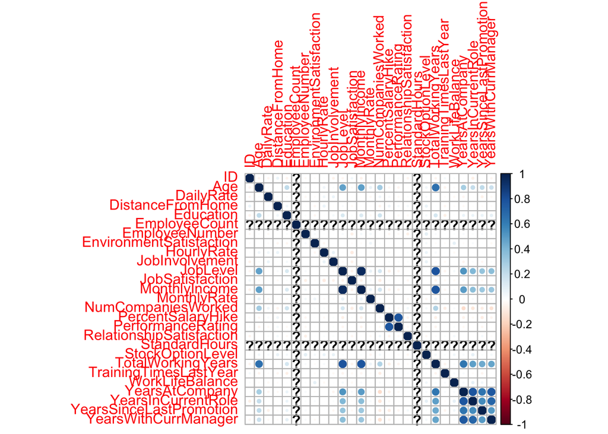

```r
corrplot(correlations, method = "circle")
```

```r
# Selected the 4 most correlated columns
predictors = c('JobLevel', 'TotalWorkingYears', 'YearsAtCompany', 'Age')

# Prepare the data
X = csd4[, predictors]
y = csd4$MonthlyIncome

# Splitting the dataset into training and testing sets
set.seed(42)
trainIndex <- createDataPartition(y, p = .7, list = FALSE)
X_train <- X[trainIndex, ]
y_train <- y[trainIndex]
X_test <- X[-trainIndex, ]
y_test <- y[-trainIndex]

# Train the linear regression model
model7 =lm(y_train ~ ., data = as.data.frame(X_train))
summary(model7)
```

```
##
## Call:
## lm(formula = y_train ~ ., data = as.data.frame(X_train))
##
## Residuals:
##     Min      1Q  Median      3Q     Max
## -4402.0  -892.9    14.9   721.7  3810.8
##
## Coefficients:
##                    Estimate Std. Error t value Pr(>|t|)
## (Intercept)       -1758.525    270.331  -6.505 1.63e-10 ***
## JobLevel           3650.338     84.734  43.080  < 2e-16 ***
## TotalWorkingYears    80.293     15.696   5.116 4.21e-07 ***
## YearsAtCompany      -36.979     12.298  -3.007  0.00275 **
## Age                   3.331      8.257   0.403  0.68681
## ---
## Signif. codes:  0 '***' 0.001 '**' 0.01 '*' 0.05 '.' 0.1 ' ' 1
##
## Residual standard error: 1366 on 605 degrees of freedom
## Multiple R-squared:  0.9128, Adjusted R-squared:  0.9123
## F-statistic:  1584 on 4 and 605 DF,  p-value: < 2.2e-16
```

```r
# Predict and calculate RMSE
predictions = predict(model7, newdata = as.data.frame(X_test))
rmse = sqrt(mean((predictions - y_test)^2))
rmse
```

```
## [1] 1432.006
```

Load in blank data and predict

```r
valsal=read.csv("/Users/christopherjohnson/Downloads/CaseStudy2Compset+No+Salary.csv",header = TRUE, stringsAsFactors = TRUE)
salaryval=predict(model7,valsal)

valsal$MonthlyIncome=salaryval
write.csv(valsal[,c("ID","MonthlyIncome")],file="/Users/christopherjohnson/Downloads/Case2PredictionJohnsonSalary.csv")
```